# Magmatic activity and plate motion during the “latent stage” of Midcontinent Rift development

Corresponding Author: Nicholas L. Swanson-Hysell (swanson-hysell@berkeley.edu)

This notebook contains data analysis used for the paper entitled *Magmatic activity and plate motion during the latent stage of Midcontinent Rift development* published in the journal GEOLOGY in 2014. The article is availible in the UC eScholarship repository: http://escholarship.org/uc/item/989179cs. The citation information is provided in bibtex format below:

@article{Swanson-Hysell2014a, Author = {Swanson-Hysell, Nicholas L. and Burgess, Seth D. and Maloof, Adam C. and Bowring, Samuel A.}, Doi = {10.1130/G35271.1}, Journal = {Geology}, Title = {Magmatic activity and plate motion during the latent stage of {M}idcontinent {R}ift development}, Year = {2014}}

### Preamble materials

Import necessary libraries and start the interactive pylab environment. The code below uses the pmag.py and pmagplotlib.py files of the the PmagPy software package (version pmagpy-2.206) authored by Lisa Tauxe (https://github.com/ltauxe/PmagPy) and the IPmag.py function library that modifies some of these functions for use in the IPython environment (https://github.com/Swanson-Hysell/PmagPy_IPython). The check_updates and get_version functions of the PmagPy libraries cause errors in the interactive environment of IPython so the code below calls a slightly modified version of the libraries that are included in the Github repository for this work. The IPmag.py function library is included within the Github repository as well as an archive of the exact code that was used in the analysis.

```python
import pandas
from IPython.core.display import HTML
import pmag
import IPmag
import pmagplotlib
```

```python
%pylab inline
```

### Import Mamainse Point paleomagnetic data

Import the data as a pandas dataframe and display the first 5 rows.

```python
Mamainse_Data_all=pandas.read_csv('../Data/Mamainse_Point_data.csv',sep=',')
Mamainse_Data_all.head()
```

|  | stratigraphic_section | section_meter_level | composite_meter_level | site_lat | site_long | n | D_geo | I_geo | D_tilt-cor | I_tilt-cor | a_95 | k | fit_used |
| --- | --- | --- | --- | --- | --- | --- | --- | --- | --- | --- | --- | --- | --- |
| 0 | MP101 | 0.0 to 15.5 | 68 | 47.0988 | -84.7123 | 6 | 203.2 | -50.3 | 131.6 | -63.2 | 9.2 | 54 | mag |
| 1 | MP101 | 15.5 to 16.8 | 84 | 47.0987 | -84.7124 | 3 | 225.0 | -47.2 | 146.0 | -77.2 | 13.7 | 54 | mag |
| 2 | MP101 | 16.8 to 18.7 | 85 | 47.0986 | -84.7124 | 5 | 226.7 | -52.8 | 120.3 | -77.5 | 7.4 | 88 | mag |
| 3 | MP101 | 20.7 to 21.3 | 89 | 47.0986 | -84.7125 | 4 | 209.1 | -46.8 | 141.5 | -66.4 | 8.4 | 121 | mag |
| 4 | MP101 | 21.3 to 21.9 | 89 | 47.0986 | -84.7126 | 6 | 218.3 | -52.3 | 126.6 | -72.7 | 4.5 | 189 | mag |

### Reversal tests on directional data from the succession

Create a list of unit vectors from the data frame to use for the statistical tests.

```python
MP_DIdata=[]
for n in range(0,len(Mamainse_Data_all)):
    Dec=Mamainse_Data_all['D_tilt-cor'][n]
    Inc=Mamainse_Data_all['I_tilt-cor'][n]
    MP_DIdata.append([Dec,Inc,1.])
```

#### First reversal

Plot the data from section MP214 which crosses the first reversal in the Mamainse Point stratigraphy and conduct a reversal test between the reversed and normal directions (Watson's V test with simulation and McFadden and McElhinny (1990) classification criteria).

```
Results of Watson V test:

Watson's V:           6.8
Critical value of V:  7.5
"Pass": Since V is less than Vcrit, the null hypothesis
that the two populations are drawn from distributions
that share a common mean direction can not be rejected.

M&M1990 classification:

Angle between data set means: 9.2
Critical angle for M&M1990:   9.7
The McFadden and McElhinny (1990) classification for
this test is: 'B'
```

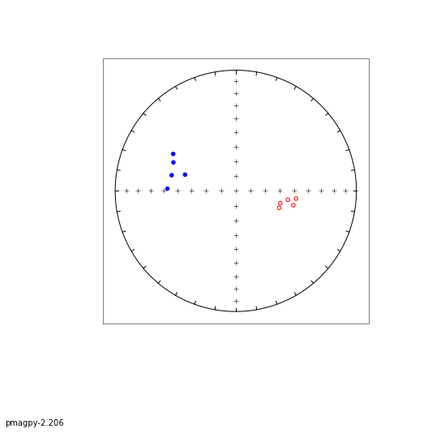

```python
MP214r=MP_DIdata[33:38]
MP214n=MP_DIdata[38:43]

fignum = 1 #set the figure number here
pylab.figure(num=fignum,figsize=(8,8),dpi=160) #size and resolution can be changed here
pmagplotlib.plotNET(fignum)
IPmag.iplotDI(MP214r,'r')
IPmag.iplotDI(MP214n,'b')

#the nested iflip function takes the antipode of the MP214r data to conduct the Watson V test for a common mean
IPmag.iWatsonV(IPmag.iflip(MP214r),MP214n)
```

#### Second reversal

Plot the data from the normal polarity zone below and the reversed polarity zone above the second reversal in the Mamainse Point stratigraphy. Conduct a reversal test between the reversed and normal directions (Watson's V test with simulation and McFadden and McElhinny (1990) classification criteria).

```
Results of Watson V test:

Watson's V:           0.9
Critical value of V:  6.3
"Pass": Since V is less than Vcrit, the null hypothesis
that the two populations are drawn from distributions
that share a common mean direction can not be rejected.

M&M1990 classification:

Angle between data set means: 3.2
Critical angle for M&M1990:   8.6
The McFadden and McElhinny (1990) classification for
this test is: 'B'
```

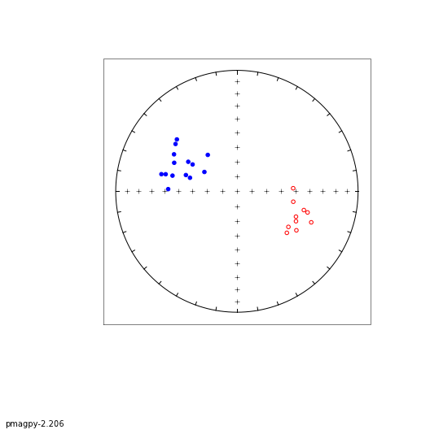

```python
MPlowerN=MP_DIdata[38:52]
MPupperR=MP_DIdata[55:65]

fignum = 2 #set the figure number here
pylab.figure(num=fignum,figsize=(8,8),dpi=160) #size and resolution can be changed here
pmagplotlib.plotNET(fignum)
IPmag.iplotDI(MPlowerN,'b')
IPmag.iplotDI(MPupperR,'r')

#the nested iflip function takes the antipode of the MPupperR data to conduct the Watson V test for a common mean
IPmag.iWatsonV(IPmag.iflip(MPupperR),MPlowerN)
```

#### Third reversal

Plot the data from the reversed polarity zone below and first 1000 meters of the normal polarity zone above the third reversal in the Mamainse Point stratigraphy. Conduct a reversal test between the reversed and normal directions (Watson's V test with simulation and McFadden and McElhinny (1990) classification criteria).

```
Results of Watson V test:

Watson's V:           5.2
Critical value of V:  6.8
"Pass": Since V is less than Vcrit, the null hypothesis
that the two populations are drawn from distributions
that share a common mean direction can not be rejected.

M&M1990 classification:

Angle between data set means: 5.7
Critical angle for M&M1990:   6.5
The McFadden and McElhinny (1990) classification for
this test is: 'B'
```

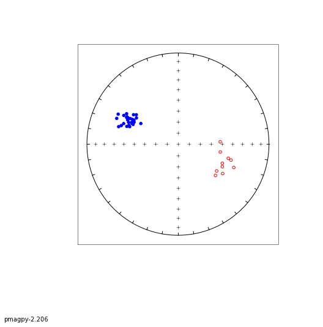

```python
MPupperR=MP_DIdata[55:65]
MPupperN=MP_DIdata[65:92]

fignum = 2 #set the figure number here
pylab.figure(num=fignum,figsize=(8,8),dpi=160) #size and resolution can be changed here
pmagplotlib.plotNET(fignum)
IPmag.iplotDI(MPupperN,'b')
IPmag.iplotDI(MPupperR,'r')

#the nested iflip function takes the antipode of the MPupperR data to conduct the Watson V test for a common mean
IPmag.iWatsonV(IPmag.iflip(MPupperR),MPupperN)
```

### Calculate Mamainse Point paleomagnetic poles

Create an empty dataframe that will be populated with pole means.

```python
pole_means = pandas.DataFrame(columns=['name','pole_lat','pole_long','A_95','N'], index=['lower_R1','lower_R2','lower_N_upper_R','upper_N','upper_N_woMP306'])
pole_means
```

|  | name | pole_lat | pole_long | A_95 | N |
| --- | --- | --- | --- | --- | --- |
| lower_R1 | NaN | NaN | NaN | NaN | NaN |
| lower_R2 | NaN | NaN | NaN | NaN | NaN |
| lower_N_upper_R | NaN | NaN | NaN | NaN | NaN |
| upper_N | NaN | NaN | NaN | NaN | NaN |
| upper_N_woMP306 | NaN | NaN | NaN | NaN | NaN |

Using the site directional data and site locations within the dataframe calculate the virtual geomagnetic pole positions. Once calculated display the first 5 rows of the now expanded Mamainse_Data_all dataframe.

```python
#calculate the paleolatitude/colatitude
Mamainse_Data_all['paleolatitude']=np.degrees(np.arctan(0.5*np.tan(np.radians(Mamainse_Data_all['I_tilt-cor']))))
Mamainse_Data_all['colatitude']=90-Mamainse_Data_all['paleolatitude']
#calculate the latitude of the pole
Mamainse_Data_all['pole_lat']=np.degrees(np.arcsin(np.sin(np.radians(Mamainse_Data_all['site_lat']))*
                                                         np.cos(np.radians(Mamainse_Data_all['colatitude']))+
                                                         np.cos(np.radians(Mamainse_Data_all['site_lat']))*
                                                         np.sin(np.radians(Mamainse_Data_all['colatitude']))*
                                                         np.cos(np.radians(Mamainse_Data_all['D_tilt-cor']))))
#calculate the longitudinal difference between the pole and the site (beta)
Mamainse_Data_all['beta']=np.degrees(np.arcsin((np.sin(np.radians(Mamainse_Data_all['colatitude']))*
                                      np.sin(np.radians(Mamainse_Data_all['D_tilt-cor'])))/
                                     (np.cos(np.radians(Mamainse_Data_all['pole_lat'])))))
#generate a boolean array (mask) to use to distinguish between the two possibilities for pole longitude
#and then calculate pole longitude using the site location and calculated beta
mask = np.cos(np.radians(Mamainse_Data_all['colatitude']))>np.sin(np.radians(Mamainse_Data_all['site_lat']))*np.sin(np.radians(Mamainse_Data_all['pole_lat']))
Mamainse_Data_all['pole_long']=np.where(mask,(Mamainse_Data_all['site_long']+Mamainse_Data_all['beta'])%360.,(Mamainse_Data_all['site_long']+180-Mamainse_Data_all['beta'])%360.)
#calculate the antipode of the poles
Mamainse_Data_all['pole_lat_rev']=-Mamainse_Data_all['pole_lat']
Mamainse_Data_all['pole_long_rev']=(Mamainse_Data_all['pole_long']-180.)%360.
Mamainse_Data_all.head()
```

|  | stratigraphic_section | section_meter_level | composite_meter_level | site_lat | site_long | n | D_geo | I_geo | D_tilt-cor | I_tilt-cor | a_95 | k | fit_used | paleolatitude | colatitude | pole_lat | beta | pole_long | pole_lat_rev | pole_long_rev |
| --- | --- | --- | --- | --- | --- | --- | --- | --- | --- | --- | --- | --- | --- | --- | --- | --- | --- | --- | --- | --- |
| 0 | MP101 | 0.0 to 15.5 | 68 | 47.0988 | -84.7123 | 6 | 203.2 | -50.3 | 131.6 | -63.2 | 9.2 | 54 | mag | -44.707215 | 134.707215 | -56.775933 | 75.926276 | 19.361424 | 56.775933 | 199.361424 |
| 1 | MP101 | 15.5 to 16.8 | 84 | 47.0987 | -84.7124 | 3 | 225.0 | -47.2 | 146.0 | -77.2 | 13.7 | 54 | mag | -65.563482 | 155.563482 | -64.207227 | 32.116906 | 63.170694 | 64.207227 | 243.170694 |
| 2 | MP101 | 16.8 to 18.7 | 85 | 47.0986 | -84.7124 | 5 | 226.7 | -52.8 | 120.3 | -77.5 | 7.4 | 88 | mag | -66.088013 | 156.088013 | -53.985198 | 36.525485 | 58.762115 | 53.985198 | 238.762115 |
| 3 | MP101 | 20.7 to 21.3 | 89 | 47.0986 | -84.7125 | 4 | 209.1 | -46.8 | 141.5 | -66.4 | 8.4 | 121 | mag | -48.853737 | 138.853737 | -64.443167 | 71.706913 | 23.580587 | 64.443167 | 203.580587 |
| 4 | MP101 | 21.3 to 21.9 | 89 | 47.0986 | -84.7126 | 6 | 218.3 | -52.3 | 126.6 | -72.7 | 4.5 | 189 | mag | -58.079957 | 148.079957 | -56.757528 | 50.744843 | 44.542557 | 56.757528 | 224.542557 |

Now that the virtual paleomagnetic poles have been calculated from the directional data, calculate mean paleomagnetic poles as the Fisher means of the VGPs in stratigraphic groupings. After these poles are calculated using the fisher_mean function in the pmag.py library, they are added to the pole_means dataframe.

```python
MPlowerR1_VGPs=[]
for n in range(0,24):
    Plong,Plat=Mamainse_Data_all['pole_long_rev'][n],Mamainse_Data_all['pole_lat_rev'][n]
    MPlowerR1_VGPs.append([Plong,Plat,1.])
MPlowerR1_mean=pmag.fisher_mean(MPlowerR1_VGPs)


pole_means.loc['lower_R1'] = pandas.Series({'name':'lower R pole 1',
                                   'pole_lat':str(round(MPlowerR1_mean['inc'],1)),
                                   'pole_long':str(round(MPlowerR1_mean['dec'],1)),
                                   'A_95':str(round(MPlowerR1_mean['alpha95'],1)),
                                   'N':str(int(MPlowerR1_mean['n']))})

MPlowerR2_VGPs=[]
for n in range(24,38):
    Plong,Plat=Mamainse_Data_all['pole_long_rev'][n],Mamainse_Data_all['pole_lat_rev'][n]
    MPlowerR2_VGPs.append([Plong,Plat,1.])
MPlowerR2_mean=pmag.fisher_mean(MPlowerR2_VGPs)


pole_means.loc['lower_R2'] = pandas.Series({'name':'lower R pole 2',
                                   'pole_lat':str(round(MPlowerR2_mean['inc'],1)),
                                   'pole_long':str(round(MPlowerR2_mean['dec'],1)),
                                   'A_95':str(round(MPlowerR2_mean['alpha95'],1)),
                                   'N':str(int(MPlowerR2_mean['n']))})

MPlower_N_upper_R_VGPs=[]
for n in range(38,52):
    Plong,Plat=Mamainse_Data_all['pole_long'][n],Mamainse_Data_all['pole_lat'][n]
    MPlower_N_upper_R_VGPs.append([Plong,Plat,1.])
for n in range(55,65):
    Plong,Plat=Mamainse_Data_all['pole_long_rev'][n],Mamainse_Data_all['pole_lat_rev'][n]
    MPlower_N_upper_R_VGPs.append([Plong,Plat,1.])
MPlower_N_upper_R_mean=pmag.fisher_mean(MPlower_N_upper_R_VGPs)

pole_means.loc['lower_N_upper_R'] = pandas.Series({'name':'lower N and upper R',
                                   'pole_lat':str(round(MPlower_N_upper_R_mean['inc'],1)),
                                   'pole_long':str(round(MPlower_N_upper_R_mean['dec'],1)),
                                   'A_95':str(round(MPlower_N_upper_R_mean['alpha95'],1)),
                                   'N':str(int(MPlower_N_upper_R_mean['n']))})

MPupper_N_VGPs=[]
for n in range(65,99):
    Plong,Plat=Mamainse_Data_all['pole_long'][n],Mamainse_Data_all['pole_lat'][n]
    MPupper_N_VGPs.append([Plong,Plat,1.])
MPupper_N_mean=pmag.fisher_mean(MPupper_N_VGPs)

pole_means.loc['upper_N'] = pandas.Series({'name':'upper N',
                                   'pole_lat':str(round(MPupper_N_mean['inc'],1)),
                                   'pole_long':str(round(MPupper_N_mean['dec'],1)),
                                   'A_95':str(round(MPupper_N_mean['alpha95'],1)),
                                   'N':str(int(MPupper_N_mean['n']))})

MPupper_N_woMP306_VGPs=[]
for n in range(65,92):
    Plong,Plat=Mamainse_Data_all['pole_long'][n],Mamainse_Data_all['pole_lat'][n]
    MPupper_N_woMP306_VGPs.append([Plong,Plat,1.])
MPupper_N_woMP306_mean=pmag.fisher_mean(MPupper_N_woMP306_VGPs)

pole_means.loc['upper_N_woMP306'] = pandas.Series({'name':'upper N (w/o MP306)',
                                   'pole_lat':str(round(MPupper_N_woMP306_mean['inc'],1)),
                                   'pole_long':str(round(MPupper_N_woMP306_mean['dec'],1)),
                                   'A_95':str(round(MPupper_N_woMP306_mean['alpha95'],1)),
                                   'N':str(int(MPupper_N_woMP306_mean['n']))})

pole_means
```

|  | name | pole_lat | pole_long | A_95 | N |
| --- | --- | --- | --- | --- | --- |
| lower_R1 | lower R pole 1 | 49.5 | 227.0 | 5.3 | 24 |
| lower_R2 | lower R pole 2 | 37.5 | 205.2 | 4.5 | 14 |
| lower_N_upper_R | lower N and upper R | 36.1 | 189.7 | 4.9 | 24 |
| upper_N | upper N | 31.2 | 183.2 | 2.5 | 34 |
| upper_N_woMP306 | upper N (w/o MP306) | 33.7 | 183.1 | 2.0 | 27 |

### Comparision between Mamainse Point VGPs and other Midcontinent Rift VGPs

#### Comparision between Siemens Creek Volcanics VGPs and Mamainse Point lower R pole 1 VGPs

Import data from the Siemens Creek Volcanics (Palmer and Halls, 1986) from sites 15 to 24 which are those that the authors argue come from the panel with the most robust tilt-correction. Tests for a common mean are conducted between these data and data from the lower reversed polarity zone of Mamainse Point (the lowermost 600 meters of stratigraphy; flows used for Mamainse Point lower R pole 1).

```python
SCV_VGP=[]
SCV_Plong=[]
SCV_Plat=[]

data_file='../Data/SCV_VGP.txt'
f=open(data_file,'rU')
for line in f.readlines():
    rec=line.split()
    Plong,Plat=float(rec[0]),float(rec[1])
    SCV_VGP.append([Plong,Plat,1.])
    SCV_Plong.append(Plong)
    SCV_Plat.append(Plat)
```

```
Results of Watson V test:

Watson's V:           5.5
Critical value of V:  6.6
"Pass": Since V is less than Vcrit, the null hypothesis
that the two populations are drawn from distributions
that share a common mean direction can not be rejected.

M&M1990 classification:

Angle between data set means: 9.5
Critical angle for M&M1990:   10.4
The McFadden and McElhinny (1990) classification for
this test is: 'C'

===============

Here are the results of the bootstrap test for a common mean
```

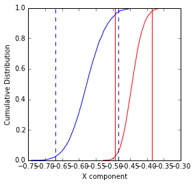

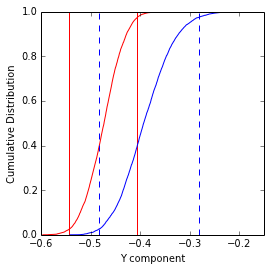

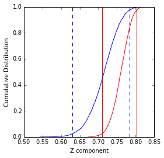

```python
#Conduct the Watson V and Bootstrap tests for a common mean
IPmag.iWatsonV(MPlowerR1_VGPs,SCV_VGP)
IPmag.iBootstrap(MPlowerR1_VGPs,SCV_VGP)
```

#### Comparision between Osler Volcanic Group VGPs and Mamainse Point lower R pole 2 VGPs

Import data from the upper portion of the stratigraphy of the Osler Volcanics Group (upper third of the Simpson Island stratigraphy; data of Swanson-Hysell et al., in review). Tests for a common mean are conducted between these data and upper portion of the lower reversed polarity zone at Mamainse Point (flows used for Mamainse Point lower R pole 2).

```python
Osler_upperthird_VGP=[]
Osler_upperthird_Plong=[]
Osler_upperthird_Plat=[]

data_file='../Data/SI_upperthird_VGP.txt'
f=open(data_file,'rU')
for line in f.readlines():
    rec=line.split()
    Plong,Plat=float(rec[0]),float(rec[1])
    Osler_upperthird_VGP.append([Plong,Plat,1.])
    Osler_upperthird_Plong.append(Plong)
    Osler_upperthird_Plat.append(Plat)
```

```
Results of Watson V test:

Watson's V:           2.4
Critical value of V:  6.2
"Pass": Since V is less than Vcrit, the null hypothesis
that the two populations are drawn from distributions
that share a common mean direction can not be rejected.

M&M1990 classification:

Angle between data set means: 4.0
Critical angle for M&M1990:   6.5
The McFadden and McElhinny (1990) classification for
this test is: 'B'

===============

Here are the results of the bootstrap test for a common mean
```

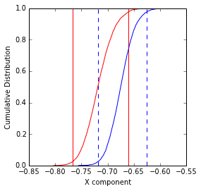

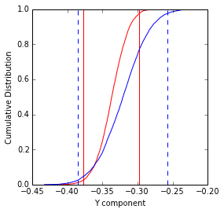

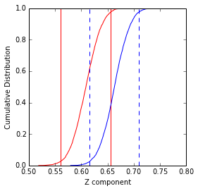

```python
#Conduct the Watson V and Bootstrap tests for a common mean
IPmag.iWatsonV(MPlowerR2_VGPs,Osler_upperthird_VGP)
IPmag.iBootstrap(MPlowerR2_VGPs,Osler_upperthird_VGP)
```

#### Comparision between SW limb of the North Shore Volcanic Group VGPs and Mamainse Point upper normal polarity zone VGPs

Import VGPs from the North Shore Volcanic Group (Tauxe and Kodama, 2009) from flows on the SW limb that are between the 40th Ave Icelandite and the Palisade Rhyolite. Tests for a common mean are conducted between these data and data from the upper normal polarity at Mamainse Point (VGPs from the 1000 meters above Great Conglomerate; upper N [w/o MP306] pole).

```python
NSVG_SWlimb_VGP=[]
NSVG_SWlimb_Plong=[]
NSVG_SWlimb_Plat=[]

data_file='../Data/NSVGsubset_VGP.txt' #This file contains data from flows on the SW limb that are between the 40th Ave Icelandite and the Palisade Rhyolite
f=open(data_file,'rU')
for line in f.readlines():
    rec=line.split()
    Plong,Plat=float(rec[0]),float(rec[1])
    NSVG_SWlimb_VGP.append([Plong,Plat,1.])
    NSVG_SWlimb_Plong.append(Plong)
    NSVG_SWlimb_Plat.append(Plat)
```

```
Results of Watson V test:

Watson's V:           2.2
Critical value of V:  6.1
"Pass": Since V is less than Vcrit, the null hypothesis
that the two populations are drawn from distributions
that share a common mean direction can not be rejected.

M&M1990 classification:

Angle between data set means: 2.2
Critical angle for M&M1990:   3.7
The McFadden and McElhinny (1990) classification for
this test is: 'A'

===============

Here are the results of the bootstrap test for a common mean
```

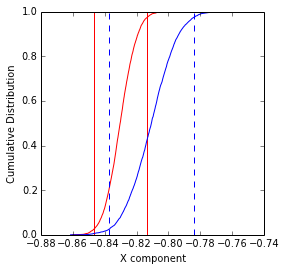

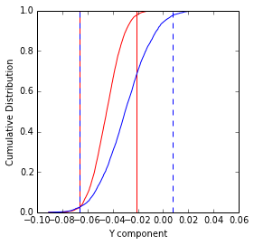

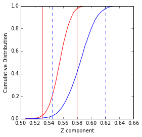

```python
#Conduct the Watson V and Bootstrap tests for a common mean
IPmag.iWatsonV(MPupper_N_woMP306_VGPs,NSVG_SWlimb_VGP)
IPmag.iBootstrap(MPupper_N_woMP306_VGPs,NSVG_SWlimb_VGP)
```

### Stratigraphic plot of VGP paleolatitude

This code takes the Mamainse Point data and creates a stratigraphic plot of the absolute value of the paleolatitude implied by each virtual geomagnetic pole. This plot was published in the supplementary materials as Figure DR3.

```python
strat_height_forplot=[]
abs_paleolatitude_forplot=[]
inclination_forplot=[]

for n in range(0,52):
    strat_height_forplot.append(Mamainse_Data_all['composite_meter_level'][n])
    abs_paleolatitude_forplot.append(numpy.absolute(Mamainse_Data_all['paleolatitude'][n]))
    inclination_forplot.append(Mamainse_Data_all['I_tilt-cor'][n])
for n in range(55,99):
    strat_height_forplot.append(Mamainse_Data_all['composite_meter_level'][n])
    abs_paleolatitude_forplot.append(numpy.absolute(Mamainse_Data_all['paleolatitude'][n]))
    inclination_forplot.append(Mamainse_Data_all['I_tilt-cor'][n])
```

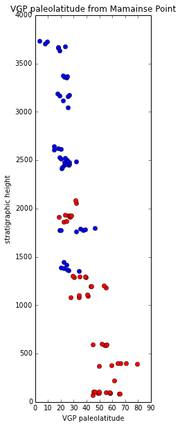

```python
for n in range(0, len(strat_height_forplot)):
    if inclination_forplot[n]>0:
        pylab.plot(abs_paleolatitude_forplot[n],strat_height_forplot[n],'bo')
        #print strat_height[item]
    elif inclination_forplot[n]<0:
        pylab.plot(abs_paleolatitude_forplot[n],strat_height_forplot[n],'ro')

plt.title("VGP paleolatitude from Mamainse Point")
plt.xlabel("VGP paleolatitude")
plt.ylabel("stratigraphic height")
pylab.xlim([0,90])
fig = matplotlib.pyplot.gcf()
fig.set_size_inches(3,10)
savefig('Mamainse_Strat.svg')
```